# Ancestry Proportions and Ancestry Grouping

Martha Richards

2026-03-16

This tutorial is owned by Florian Privé.

**What are Ancestry Proportions?**

Ancestry proportions or admixture proportions describe the ratio of an individual’s genome that can be traced back to different ancestral populations. The estimations are important in human population genetics to understand an individual’s demographic history and to correct for population structure. Population structure needs to be corrected because genetic differences across groups can look like disease associations which can lead to false results. One way of doing this is through Principal Component Analysis, which is done in the bigsnpr work package. This asks instead of “does Variant X correlate with this trait,” but “does Variant X correlate with the trait after we have already accounted for the person’s position on the PCA map?”

Ancestry proportions can give the percentage of where the individual is from geographically, for example, a person might have an estimated ancestry proportion of 60% West African, 30% European, and 10% East Asian. These are not family history estimates — they are calculated directly from patterns in an individual’s DNA. The results from this analysis for each individual is a set of proportions that sum to 1. How they are calculated: They can be calculated using a range of tools but here we explore two different methods from the bigsnpr package.

**Why are Ancestry Proportions important?**

Ancestry Proportions are important in many aspects’ bioinformatics. In population genetics, they reveal historical patterns of migration admixture between human populations which helps to reconstruct how modern populations formed in the past.

Ancestry inference is important in clinical medicine, as disease prevalence and drug responses often vary across ancestral backgrounds. This variation occurs not because genes change location, but because the frequency of specific risk variants and their genetic correlations (linkage disequilibrium) differ globally. For example, a genetic variant which increased your chance of having schizophrenia might be very common (found in 40% of people) in population A, but the same allele might be very rare (1%) in population B. The gene is in the same place for both groups, but the “risk” is more frequent in population A.

These variant alleles are usually inherited with their neighbour genes called linkage disequilibrium. In one ancestry a harmless “tag” variant might be inherited alongside a hidden harmful variant, yet in another ancestry, thousands of years might have broken that linkage. So, if a researcher looks for that “tag” neighbour allele in the second ancestry, they might think the patient is at risk when they weren’t. The signal has changed because the neighbour alleles are different.

Incorporating these ancestry proportions into Polygenic Risk Scores (PRS) significantly improves their predictive accuracy, leading to better treatment outcomes for all patients. This is particularly crucial for addressing health inequities, as genetic datasets have historically been Eurocentric; accounting for diverse ancestry proportions helps identify and bridge the gaps in our current genomic knowledge.

## **Estimating Ancestry Proportions from Allele Frequencies only**

### **Preparation**

```r
# Load required R Libraries
library(dplyr)
library(quadprog)
library(bigsnpr)
library(DT)
library(bigstatsr)
library(prettydoc)
library(ggplot2)
```

```r
# Download the Data used in the Tutorials
"https://figshare.com/ndownloader/files/38019072",
"https://figshare.com/ndownloader/files/38019027",
"https://figshare.com/ndownloader/files/38019024",
"https://figshare.com/ndownloader/files/38077323",
"https://figshare.com/ndownloader/files/38247288",
"http://www.epigad.org/gwas_ilae2018_16loci/all_epilepsy_METAL.gz"
"https://figshare.com/ndownloader/files/31620968"
"https://figshare.com/ndownloader/files/31620953"
bigsnpr::download_plink("tmp-data")
bigsnpr::download_plink2("tmp-data")
```

**Set up file pathway to name and store data**

```r
DIR <- "tmp-data/datasets"
```

This line stores a file path as a text string by creating a variable *DIR* This does not create the folder, access it or manipulate it, it just stores the path as a text. This makes coding easier because you don’t need to re-write the whole line which helps with reproducibility, because if you ever move your data to a different folder, you only need to change this one line.

**Naming and Storing Files**

```r
gz <- runonce::download_file(
  "http://www.epigad.org/gwas_ilae2018_16loci/all_epilepsy_METAL.gz",
  dir = "../datasets")
readLines(gz, n = 3)
```

This creates a variable called *gz* which will store the file path once it has been downloaded from the internet using the `runonce` code. The key feature is it only downloaded once, if the file already exists it skips the download, saving time and computational power.

`dir = ".../datasets"` tells R where to save the downloaded file on the computer. * `ReadLines` looks at the first three lines of the file to check the right page has been downloaded.

**Read in summary statistics, keeping only 5 key columns**

```r
sumstats <- bigreadr::fread2(
  gz, select = c("CHR", "BP", "Allele2", "Allele1", "Freq1"),
  col.names = c("chr", "pos", "a0", "a1", "freq")
) %>%
  mutate_at(3:4, toupper)
```

This creates a variable called `sumsats` which stores the data once it has been read in using the `fread2` function from the bigreadr package which can read large files quickly.

- The `select` function only reads these 5 columns from the file, ignoring everything else.
- The `col.names` renames those 5 columns into shorter cleaner names.
- The `mutate_at` function from the dplyr package applies a transformation to specific columns, and mutate means to change or modify. This code takes columns 3 and 4 (a0 and a1) and converts any lowercase letters to UPPERCASE, because alleles should always be uppercase (A, T, C, G) and the source file may have mixed cases

```r
all_freq <- bigreadr::fread2(
  runonce::download_file("https://figshare.com/ndownloader/files/31620968",
                         dir = DIR, fname = "ref_freqs.csv.gz"))
projection <- bigreadr::fread2(
  runonce::download_file("https://figshare.com/ndownloader/files/31620953",
                         dir = DIR, fname = "projection.csv.gz"))
```

This code is essentially naming files.

This creates a variable called all_freq which will store the data once it has been coded.

The file at the end of the function is the path to the file being read, csv means it is a spreadsheet style with columns separated by commas.

### **Analysis**

We need to match variants within the summary statistics with the ones from the reference by chromosome, position and alleles.

This is important for analysis because the two data sets are not automatically compatible with each other.

The *sumstats* from the epilepsy GWAS data contains;

- Variants found in epilepsy patients

While the all_freq (reference panel) contains:

- Variants from known ancestry reference populations

**Match the epilepsy GWAS variants to the reference panel by chromosome, position and alleles**

```r
matched <- snp_match(
  mutate(sumstats, chr = as.integer(chr), beta = 1),
  all_freq[1:5]
) %>%
  mutate(freq = ifelse(beta < 0, 1 - freq, freq))
```

```
## 4,880,492 variants to be matched.
```

```
## 6 ambiguous SNPs have been removed.
```

```
## 3,343,235 variants have been matched; 0 were flipped and 1,576,097 were reversed.
```

This code takes the summary statistics and the reference frequency data, finds all the variants which appear in both data sets and makes sure the allele frequencies are correct after matching.

- `snp_match` is a function from bigsnpr which matches SNPs between two data sets. It matches by chromosome, position and alleles to find the same variants.
- Before matching the `mutate` makes two small changes to `sumstats_. _chr = as.integer(chr)` converts the chromosome from a text to a whole number because `snp_match()` requires it to be a number not text (e.g. “1” to 1).
- `beta = 1` adds a new column called beta and sets every values to 1, which is a placeholder value required by `snp_match` to work.
- `all_freq[1:5]` is the reference data set being matched against and only the first 5 columns are being used because they contain the chromosome, position and allele information needed for matching.
- `mutate(freq = ifelse(beta < 0, 1 - freq, freq))` corrects the allele frequency after matching.
- `ifelse(beta < 0, 1 - freq, freq)` means: if beta is negative → replace freq with 1 - freq, f beta is positive → keep freq as it is.

This is important because when `snp_match` flips an allele to make it match, the frequency also needs to be flipped, since all frequencies must add up to 1, if one allele is 0.3 the other must be 0.7.

**Correct allele frequencies for any flipped alleles after matching**

```r
correction <- c(1, 1, 1, 1.008, 1.021, 1.034, 1.052, 1.074, 1.099,
                1.123, 1.15, 1.195, 1.256, 1.321, 1.382, 1.443)
```

- `correction` creates a variable of 16 numbers, which are the pre-calculated correction factors for each principal component. These values were calculated by the `bigsnpr` package.

This is needed because when you project a new data set onto a principal component space which was built from a different reference data set there is mathematical shrinkage effect. This step rules out systematical bias.

**Estimate ancestry proportions using the snp_ancestry_summary function and apply correction factors**

```r
res <- snp_ancestry_summary(
  freq = matched$freq,
  info_freq_ref = all_freq[matched$`_NUM_ID_`, -(1:5)],
  projection = projection[matched$`_NUM_ID_`, -(1:5)],
  correction = correction
)
```

Takes the allele frequencies and estimates what proportion of the sample comes from each ancestry group.

- `snp_ancestry_summary()` is the main function from bigsnpr which actually estimates ancestry proportions. This takes the allele frequencies and estimates what proportion of the sample comes from each ancestry group.
- `freq = matched$freq` This takes the freq column from the matched dataframe. These are the allele frequencies observed in the epilepsy patients and is the dataset you are trying to analyse.
- `info_freq_ref = all_freq[matchedNUM_ID, -(1:5)]`, provides the reference population allele frequencies to compare against.
- `matched$_NUM_ID` selects only the rows that were successfully matched earlier
- `projection = projection[matched$NUM_ID, -(1:5)]` provides the PC projection matrix for the match variants. This is used to project your data into the same PC space as the reference populations.
- `correction = correction)` - Inside the same block, which passes in the 16 pre-calculated correction numbers

**Merge similar regional groups together**

```r
group <- colnames(all_freq)[-(1:5)]
group[group %in% c("Scandinavia", "United Kingdom", "Ireland")]   <- "Europe (North West)"
group[group %in% c("Europe (South East)", "Europe (North East)")] <- "Europe (East)"
grp_fct <- factor(group, unique(group))

final_res <- tapply(res, grp_fct, sum)
round(100 * final_res, 1)
```

```
##       Africa (West)      Africa (South)       Africa (East)      Africa (North)
##                 0.7                 0.3                 0.0                 0.0
##         Middle East           Ashkenazi               Italy       Europe (East)
##                 0.0                 1.8                 3.4                13.9
##             Finland Europe (North West) Europe (South West)       South America
##                 6.5                68.0                 2.1                 0.0
##           Sri Lanka            Pakistan          Bangladesh         Asia (East)
##                 0.0                 0.0                 0.0                 3.1
##               Japan         Philippines
##                 0.3                 0.0
```

This code takes the raw ancestry results and merges groups within similar regions together into broader categories. Next the proportions are added up within each group and printed as rounded percentages.

This is important because the reference panel has detailed ancestry groups which for most research is too refined. Merging them into broader groups makes the results easier to interpret, more statistically reliable and more comparable.

- `colnames()` gets all the column names from all_freq.
- `[-(1:5)]` removes the first 5 columns which are the chromosome, position and allele information. This leaves the ancestry groups names which were used as column headers in the reference panel. So _group is now a list of ancestry names like “Africa”
- `%in%` means contained in. This finds any ancestry labels which are “Scandinavia”, “United Kingdom” or “Ireland” and mergers them into one broader group called “Europe.” This is then repeated with Eastern European groups.
- `grp_fct <- factor(group, unique(group))` converts the `group` variable into a factor (Rs way of representing categories). R needs the groups to be factors to be able to sum them up correctly in the next step.
- `unique(group)` ensures each group name only appears once.
- `tapply()` is a function which takes the ancestry proportion results in `res` and adds them up within each group. So for example all the individual European subgroup proportions get summed into one single European proportion.
- The result is stored in `final_res`
- `round(100 * final_res, 1)` The times 100 converts the proportions from decimals to percentages, which are then rounded to 1 decimal place.

### **Results**

Europe (North West): 68.0% — the dominant ancestry

Europe (East): 13.9%

Finland: 6.5%

Italy: 3.4%

Asia (East): 3.1%

Ashkenazi: 1.8%

This approach is important because you don’t need individual-level reference genomes, just the population level allele frequencies (which was the input and also publicly available.) This makes the analysis more computationally lightweight. Furthermore, having the results in percentages makes the data more readable unlike PC-based methods which require additional interpretation.

## **Estimating Ancestry Proportions from Individual-level**

### **Data Preparation**

#### **Download Data**

```r
prefix <- "https://sharehost.hms.harvard.edu/genetics/reich_lab/sgdp/variant_set/cteam_extended.v4.maf0.1perc"
bedfile <- runonce::download_file(paste0(prefix, ".bed"), dir = DIR)
famfile <- runonce::download_file(paste0(prefix, ".fam"), dir = DIR)
bim_zip <- runonce::download_file(paste0(prefix, ".bim.zip"), dir = DIR)
unzip(bim_zip, exdir = DIR, overwrite = FALSE)
```

This code downloads the genetic data files needed for the ancestry analysis.

`prefix` Stores the base web address of the files from the Reich Lab at Harvard Medical School as a shortcut, so you don’t have to type the full URL repeatedly. The dataset is the SGDP (Simons Genome Diversity Project) reference panel.

The `.bed` `.fam` `.bim.zip` are the three files whic make up a PLINK binary data set.

#### **Read in the .bim file keeping only the 4 key columns**

```r
matched <- sub_bed(bedfile, ".bim") %>%
  bigreadr::fread2(select = c(1, 4:6),
                   col.names = c("chr", "pos", "a1", "a0")) %>%
  mutate(beta = 1) %>%
  snp_match(all_freq[1:5])
```

```
## 34,418,131 variants to be matched.
```

```
## 4,365 ambiguous SNPs have been removed.
```

```
## 4,030,044 variants have been matched; 0 were flipped and 997,183 were reversed.
```

| chr | pos | a0 | a1 | beta | *NUM_ID*.ss | rsid | *NUM_ID* |
| --- | --- | --- | --- | --- | --- | --- | --- |
| 1 | 846808 | C | T | 1 | 3 | rs4475691 | 239 |
| 1 | 847228 | C | T | 1 | 13 | rs3905286 | 240 |
| 1 | 847491 | G | A | 1 | 17 | rs28407778 | 241 |
| 1 | 848090 | G | A | 1 | 24 | rs4246505 | 242 |
| 1 | 848445 | G | A | 1 | 35 | rs4626817 | 243 |
| 1 | 848456 | A | G | 1 | 36 | rs11507767 | 244 |
| 1 | 848738 | C | T | 1 | 46 | rs3829741 | 246 |
| 1 | 849998 | A | G | -1 | 75 | rs13303222 | 248 |
| 1 | 850123 | C | T | 1 | 79 | rs28622257 | 249 |
| 1 | 850780 | C | T | -1 | 86 | rs6657440 | 252 |

- `matched <- sub_bed(bedfile, ".bim")` is the name of the file.
- `bedfile` points the PLINK program to the .bed file (which houses the binary genotype data).
- `sub_bed(..., ".bim")` swaps the .bed file extension for .bim file.
- This is followed by a pipe operator where the .bim file is taken to the next command.

#### **Matching and Harmonisation**

```r
bk_path  <- "tmp-data/datasets/cteam_extended.v4.maf0.1perc.bk"
rds_path <- "tmp-data/datasets/cteam_extended.v4.maf0.1perc.rds"

if (file.exists(bk_path)) {
  file.remove(bk_path)
  file.remove(rds_path)
}

rds <- snp_readBed2(bedfile, ind.col = matched$`_NUM_ID_.ss`)
obj.bigsnp <- snp_attach(rds)
G <- obj.bigsnp$genotypes
```

Two file paths are defined for the dataset cteam_extended.v4.maf0.1perc. The suffixes tell us their purpose:

.bk — a backing file, a binary file storing the raw genotype matrix on disk .rds — an R data file, storing the metadata/object that points to the .bk file

Before creating new files, this checks if the .bk file already exists and, if so, deletes both files. This avoids errors that would occur if you tried to overwrite them — bigsnpr doesn’t allow silent overwrites.

`snp_readBed2()` reads a PLINK BED file (a standard genomic format) and converts it into bigsnpr’s format. The key argument:

`ind.col = matched$_NUM_ID_.ss` only loads a subset of SNP columns that were previously matched to a reference panel, filtering to relevant variants only

`snp_attach()` loads the `.rds` metadata file into memory, linking it to the .bk binary data on disk. The data itself stays on disk — it’s memory-mapped, meaning it can be far larger than your available RAM.

`G <- obj.bigsnp$genotypes` Pulls out the genotype matrix from the object and stores it as G. Each cell typically contains a value of 0, 1, or 2, representing the count of a reference allele for each individual × SNP combination.

#### **Quality Control**

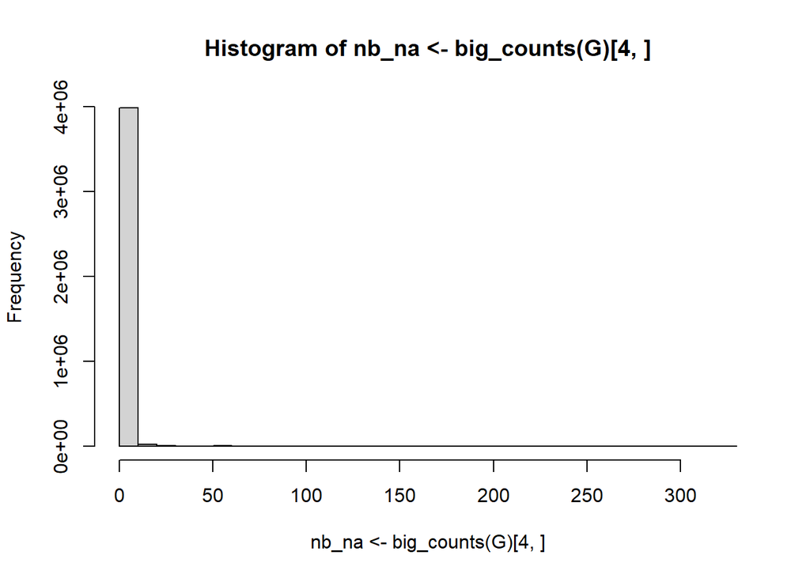

```r
hist(nb_na <- big_counts(G)[4, ])
```

`big_counts(G)` Returns a matrix where each column is a SNP and each row counts how many individuals have each genotype value:

- Row 1 = count of 0 (homozygous reference)
- Row 2 = count of 1 (heterozygous)
- Row 3 = count of 2 (homozygous alternative)
- Row 4 = count of NA (missing genotype)

`[4, ]` Selects just row 4 — the missing value counts — giving you one number per SNP representing how many individuals have missing data at that SNP.

The `nb_na <- assignment` happens inside the `hist()` call — R saves the missing counts as nb_na for use later, whilst simultaneously plotting a histogram showing the distribution of missingness across all SNPs.

```r
ind <- which(nb_na < 5)
```

- `nb_na < 5` creates a TRUE/FALSE value for every SNP, TRUE if that SNP has fewer than 5 missing genotypes across all individuals
- `which(...)` converts that to a vector of index positions (column numbers) where the condition is TRUE
- `ind <-` saves those positions as ind

```r
G2 <- snp_fastImputeSimple(G)
```

For each SNP with missing values, it replaces the NA with the most common genotype at that position (the mode). So if at a particular SNP most people have genotype 0, any missing values get filled in as 0.

- `G` genotype matrix containing 0, 1, 2, and NA values
- `snp_fastImputeSimple()` fills in the missing NA values using a simple imputation method
- `G2` <- saves the result as a new object, leaving the original G unchanged

### **Analysis**

#### **Projecting Individuals onto PC Space**

```r
# project individuals (divided by 2) onto the PC space
PROJ <- as.matrix(projection[matched$`_NUM_ID_`[ind], -(1:5)])
all_proj <- big_prodMat(G2, sweep(PROJ, 2, correction / 2, '*'),
                        ind.col = ind,
                        # scaling to get G if beta = 1 and (2 - G) if beta = -1
                        center = 1 - matched$beta[ind],
                        scale = matched$beta[ind])
```

- `projection` is a pre-computed SNP loadings matrix from the reference panel PCA — it defines the PC space
- `matched$_NUM_ID_[ind]` selects only the rows of that loadings matrix corresponding to the matched and QC-passed SNPs.
- `-(1:5)` drops the first 5 metadata columns, keeping only the numerical PC loading values
- `as.matrix()` converts it to a plain matrix ready for computation

So PROJ is now a matrix of shape SNPs × PCs, telling you how much each SNP contributes to each principal component

- `big_prodMat` performs a matrix multiplication between the genotype matrix G2 and the adjusted loadings. This is the core projection operation — mathematically multiplying each individual’s genotypes by the SNP loadings to get their position in PC space
- `sweep(PROJ, 2, correction / 2, 'x')` scales each PC loading column by a correction factor divided by 2.
- The `/2` accounts for the fact that genotypes are coded as 0/1/2 (diploid), so you divide by 2 to get per-allele contributions
- The `correction` adjusts for differences in allele frequency scaling between your data and the reference panel PCA
- `ind.col = ind`, Tells big_prodMat to only use the QC-passed SNP columns from G2.
- `all_proj` is the output matrix of individuals x PCs e.g. each row is a persons coordinates in PC space (their unique address on the ancestry map).

When `beta = 1` (allele is in the correct orientation): `center = 0, scale = 1` → uses G as-is. When `beta = -1` (allele was flipped during snp_match): `center = 2`, `scale = -1` → computes `2 - G`, which flips the allele coding back.

**Importance**

- Having the individuals placed on the map built from thousands of known ancestry samples makes the coordinates directly interpretable.
- computionally efficient
- preserves all QC decisions
- These PC coordinates are what the ancestry model will actually use to assign proportions

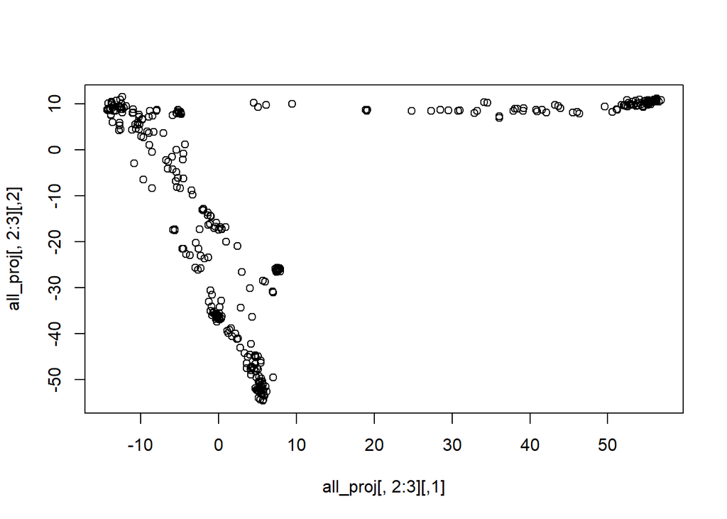

```r
plot(all_proj[, 2:3])
```

This is a visual inspection of the projected results. Essentially looking at a scatter plot where each point is a person, and their position reflects their genetic similarity to the reference populations that shaped that PC space. The reason the plot PC2 and PC3 rather than PC1 and PC2 is that PC1 in large global reference panels is very often dominated by a single massive axis of variation — typically the Africa versus non-Africa split — which can compress all the variation that is actually cared about into a tiny corner of the plot. PC2 and PC3 often reveal more nuanced and interpretable structure among your individuals.

#### **Placing Reference Populations into PC Space**

```r
X <- crossprod(PROJ,
               as.matrix(all_freq[matched$`_NUM_ID_`[ind], -(1:5)]))
```

- `all_freq[matched$_NUM_ID_[ind], -(1:5)` selects the reference panel allele frequencies for only the QC-passed matched SNPs, dropping the metadata columns
- `as.matrix()` converts to a plain matrix ready for computation
- `crossprod(PROJ, ...)` — mathematically equivalent to `t(PROJ) %*% allele_frequencies`, multiplying the allele frequencies through the same projection matrix used for individuals

#### **Solving the Optimisation Problem**

For each individual, what mixture of reference populations best matches where this person sits on the ancestry map. Proportions must add up to exactly 1 (100%) and no proportion can be negative

```r
cp_X_pd <- Matrix::nearPD(crossprod(X), base.matrix = TRUE)
Amat <- cbind(1, diag(ncol(X)))
bvec <- c(1, rep(0, ncol(X)))
```

- `crossprod(X)_ computes t(X) %% X` = a populations × populations matrix capturing how similar reference populations are to each other in PC space
- `nearPD()` finds the nearest positive definite version of that matrix — this is a mathematical requirement for QP solvers, essentially ensuring the optimisation problem is well-behaved and has a unique solution. Without this step the solver could fail or produce nonsensical results if reference populations are very similar to each other
- Amat`and`bvec` together enforce two rules:
  - All ancestry proportions must sum to exactly 1 (you can’t have 120% ancestry)
  - All ancestry proportions must be ≥ 0 (you can’t have negative ancestry)

The solver cannot solve the optimisation problem without the constraints being built in — if you removed the constraints it might produce nonsensical answers like negative ancestry or proportions adding up to 150%.

**For each individual, what mixture of reference populations best matches?**_

```r
all_res <- apply(all_proj, 1, function(y) {
  quadprog::solve.QP(
    Dmat = cp_X_pd$mat,
    dvec = crossprod(y, X),
    Amat = Amat,
    bvec = bvec,
    meq  = 1
  )$sol %>%
    tapply(grp_fct, sum) %>%
    round(7)})
```

- `apply(..., 1, ...)` runs the function once per row of all_proj — meaning once per individual
- `y` is each individual’s vector of PC coordinates — their position on the ancestry map
- `Dmat` = the population similarity matrix (how reference populations relate to each other)
- `dvec = crossprod(y, X)` shows how closely this individual’s PC position matches each reference population — the key comparison between `all_proj` and `X`
- `meq = 1` tells the solver that the first constraint is an equality (proportions must sum to exactly 1)
- `$sol` extracts the solution — a vector of ancestry proportions, one per reference population
- `tapply` collapses sub-populations into broader regional groups by summing their proportions
- `round(7)` keeps 7 decimal places for precision at this stage

**Why this is important?**

The QC approach is more powerful because it allows mixtures real people have mixed ancestry, not pure population membership. Also proportions are guaranteed to be valid because they sum up to 1, and this analysis accounts for the fact that reference populations overlap and are not independent.

### **Results**

#### **Metadata**

```r
fam2 <- bigreadr::fread2("https://sharehost.hms.harvard.edu/genetics/reich_lab/sgdp/SGDP_metadata.279public.21signedLetter.44Fan.samples.txt")
```

This downloads and reads the metadata file directly from the Reich Lab website into R.

```r
fam <- dplyr::left_join(obj.bigsnp$fam, fam2, by = c("sample.ID" = "Sample_ID(Aliases)"))
```

Matches the sample IDs from your genotype data to the metadata file so each individual gets their region, country and population label attached.

```r
fam_info <- fam[c("Region", "Country", "Population_ID")]
```

Subsets the joined data to keep only the three key identifying columns — region, country and population — ready to be combined with the ancestry proportion results.

#### **Final Table**

Joins the known origin information side by side with the estimated ancestry proportions

```r
cbind.data.frame(fam_info, round(100 * t(all_res), 1)) %>%
  rmarkdown::paged_table(list(rows.print = 15, max.print = nrow(fam)))
```

| Region | Country | Population_ID | Africa (West) | Africa (South) | Africa (East) | Africa (North) | Middle East | Ashkenazi | Italy | Europe (East) | Finland | Europe (North West) | Europe (South West) | South America | Sri Lanka | Pakistan | Bangladesh | Asia (East) | Japan | Philippines |
| --- | --- | --- | --- | --- | --- | --- | --- | --- | --- | --- | --- | --- | --- | --- | --- | --- | --- | --- | --- | --- |
| Africa | Algeria | Mozabite | 1.7 | 0.0 | 0.0 | 98.3 | 0.0 | 0.0 | 0.0 | 0.0 | 0.0 | 0.0 | 0.0 | 0.0 | 0.0 | 0.0 | 0.0 | 0.0 | 0.0 | 0.0 |
| Africa | Algeria | Mozabite | 11.0 | 0.0 | 0.0 | 89.0 | 0.0 | 0.0 | 0.0 | 0.0 | 0.0 | 0.0 | 0.0 | 0.0 | 0.0 | 0.0 | 0.0 | 0.0 | 0.0 | 0.0 |
| Africa | Western Sahara (Morocco) | Saharawi | 0.7 | 0.0 | 0.0 | 99.3 | 0.0 | 0.0 | 0.0 | 0.0 | 0.0 | 0.0 | 0.0 | 0.0 | 0.0 | 0.0 | 0.0 | 0.0 | 0.0 | 0.0 |
| Africa | Western Sahara (Morocco) | Saharawi | 2.8 | 0.0 | 0.0 | 97.2 | 0.0 | 0.0 | 0.0 | 0.0 | 0.0 | 0.0 | 0.0 | 0.0 | 0.0 | 0.0 | 0.0 | 0.0 | 0.0 | 0.0 |
| Africa | BotswanaOrNamibia | BantuHerero | 22.1 | 77.9 | 0.0 | 0.0 | 0.0 | 0.0 | 0.0 | 0.0 | 0.0 | 0.0 | 0.0 | 0.0 | 0.0 | 0.0 | 0.0 | 0.0 | 0.0 | 0.0 |
| Africa | BotswanaOrNamibia | BantuHerero | 25.3 | 74.7 | 0.0 | 0.0 | 0.0 | 0.0 | 0.0 | 0.0 | 0.0 | 0.0 | 0.0 | 0.0 | 0.0 | 0.0 | 0.0 | 0.0 | 0.0 | 0.0 |
| Africa | BotswanaOrNamibia | BantuTswana | 0.0 | 100.0 | 0.0 | 0.0 | 0.0 | 0.0 | 0.0 | 0.0 | 0.0 | 0.0 | 0.0 | 0.0 | 0.0 | 0.0 | 0.0 | 0.0 | 0.0 | 0.0 |
| Africa | BotswanaOrNamibia | BantuTswana | 0.0 | 100.0 | 0.0 | 0.0 | 0.0 | 0.0 | 0.0 | 0.0 | 0.0 | 0.0 | 0.0 | 0.0 | 0.0 | 0.0 | 0.0 | 0.0 | 0.0 | 0.0 |
| Africa | Cameroon | Mada | 58.7 | 26.5 | 14.8 | 0.0 | 0.0 | 0.0 | 0.0 | 0.0 | 0.0 | 0.0 | 0.0 | 0.0 | 0.0 | 0.0 | 0.0 | 0.0 | 0.0 | 0.0 |
| Africa | Cameroon | Mada | 61.6 | 22.4 | 16.0 | 0.0 | 0.0 | 0.0 | 0.0 | 0.0 | 0.0 | 0.0 | 0.0 | 0.0 | 0.0 | 0.0 | 0.0 | 0.0 | 0.0 | 0.0 |

[output cut: 335 more lines]

This is the comparison step — it joins the known origin information side by side with the estimated ancestry proportions `t(all_res)` * `all_res` is stored as populations × individuals (each column is a person) * `t()` transposes it to individuals × populations (each row is a person) * This makes it match fam_info where each row is also a person

`round(100 * t(all_res), 1)` * Multiplying by 100 converts proportions (0.45) into percentages (45%) * `round(..., 1)` rounds to 1 decimal place so the table is readable

`cbind.data.frame(fam_info, round(100 * t(all_res), 1))` * `cbind` stands for column bind, it glues two tables together side by side * `Left side: fam_info` the region, country and population columns * `Right side`: the ancestry percentages * The result is one combined table where each row shows a person’s known origin alongside their estimated ancestry proportions

This allows direct comparison between estimated ancestry and known geographic origin.

## **Grouping**

**What is ancestry grouping?**

This is the process of organising individuals into groups based on their genetic ancestry. Ancestry grouping is a qualitative step which assigns people to discrete populations or clusters.

Ancestry grouping uses genotype data while the other two methods have used population frequency summaries or raw individual genotypes. The key insight is that ancestry grouping defines who the reference populations are, while the two estimation approaches differ in what data you use to compare against those references.

**Code**

The code assigns each individual to the nearest reference population in PC space, but only if they’re close enough (within a scaled distance threshold). Anyone too far from all reference populations gets flagged as NA — i.e., they don’t fit cleanly into any group. This is essentially a nearest-centroid classifier with a rejection option.

```r
PC_SGDP <- all_proj
all_centers <- t(X)
all_sq_dist <- apply(all_centers, 1, function(one_center) {
  rowSums(sweep(PC_SGDP, 2, one_center, '-')^2)
})

thr_fst <- 0.005  # you can adjust this threshold
thr_sq_dist <- max(dist(all_centers)^2) * thr_fst / 0.16

cluster <- group[
  apply(all_sq_dist, 1, function(x) {
    ind <- which.min(x)
    if (isTRUE(x[ind] < thr_sq_dist)) ind else NA
  })
]

table(cluster, exclude = NULL)
```

```
## cluster
##       Africa (East)      Africa (North)      Africa (South)       Africa (West)
##                  11                   6                  32                  23
##         Asia (East)          Bangladesh       Europe (East) Europe (North West)
##                  32                   3                  10                   9
## Europe (South West)             Finland               Italy               Japan
##                   8                   5                   8                  17
##         Middle East            Pakistan         Philippines       South America
##                  32                  17                   8                   1
##           Sri Lanka                <NA>
##                  18                 105
```

**Setup**

`PC_SGDP <- all_proj` assigns the projected PCA coordinates of target individuals. Each row is an individual, each column is a PC axis.

`all_centres <- t(X)` transposes X to ge the cluster centers (reference populations in PC space.) After this step each row is a population center and each column is a PC axis.

**Computing Squared Distances**

For each `once_centre`

- `sweep(...., 2, one_centre, '-')` subtracts that centers coordinates from every individual’s PC coordinates
- `^2` squares the difference
- `rowSums()` sums across the PC axis which gives the squared **Euclidean distance** from each individual to that center.

The result is `all_sq_dist` matrix [n_individuals x n_populations] which is the squared distance from every individual to every population center.

**Setting the Distance Threshold**

`thr_fst <- 0.005` this means that individuals must be closer to a center to be assigned.

`thr_sq_dist <- max(dist(all_centers)^2) * thr_fst / 0.16`

- Converts `thr_fst` into a swuared PC distance threshold
- `dist(all_centers)^2` this is the pairwise squared distances between population centers
- `max(...)` this takes the largest squared distance
- `* thr_fst / 0.16` scales the distance. `o.16` is a calibration constant.

This makes the threshold relative to how spread apart the reference populations are.

**Assigning Cluster Labels**

- For each individual (row of `all_sq_dist`)
- `which.min(x)` finds the index of the nearest population center
- `if (x[ind] < thr_sq_dist)` checks whether that nearest distance is within the threshold.
  - If yes → returns the index → used to look up the population label in group
  - If no → returns NA (individual is too far from any center → unassigned)
- `group` is a vector of population names, so this maps numeric indices back to labels.

**Combining two ancestry estimation approaches**

```r
cluster[all_res["South America", ] > 0.9] <- "South America"

table(cluster, exclude = NULL)
```

```
## cluster
##       Africa (East)      Africa (North)      Africa (South)       Africa (West)
##                  11                   6                  32                  23
##         Asia (East)          Bangladesh       Europe (East) Europe (North West)
##                  32                   3                  10                   9
## Europe (South West)             Finland               Italy               Japan
##                   8                   5                   8                  17
##         Middle East            Pakistan         Philippines       South America
##                  32                  17                   8                  25
##           Sri Lanka                <NA>
##                  18                  81
```

- `all_res["South America", ]` extracts the row corresponding to “South America” from all_res, which is likely a matrix of estimated ancestry proportions (individuals as columns, ancestries as rows)
- `> 0.9` creates a vector: TRUE for individuals where South American ancestry proportion exceeds 90%
- `cluster[...]` selects those individuals from the cluster vector
- `<- "South America"`reassigns them to “South America” regardless of what the PC-distance clustering said

The table prints the updates counts of cluster assignmnets, including NA so you cansee how many individuals remain unassigned after the override.

```r
cbind.data.frame(fam_info, Assigned_group = cluster) %>%
  rmarkdown::paged_table(list(rows.print = 15, max.print = nrow(fam)))
```

| Region | Country | Population_ID | Assigned_group |
| --- | --- | --- | --- |
| Africa | Algeria | Mozabite | Africa (North) |
| Africa | Algeria | Mozabite | Africa (North) |
| Africa | Western Sahara (Morocco) | Saharawi | Africa (North) |
| Africa | Western Sahara (Morocco) | Saharawi | Africa (North) |
| Africa | BotswanaOrNamibia | BantuHerero | Africa (South) |
| Africa | BotswanaOrNamibia | BantuHerero | Africa (South) |
| Africa | BotswanaOrNamibia | BantuTswana | Africa (South) |
| Africa | BotswanaOrNamibia | BantuTswana | Africa (South) |
| Africa | Cameroon | Mada | Africa (West) |
| Africa | Cameroon | Mada | Africa (West) |

[output cut: 335 more lines]

- `fam_info` an existing data frame containing sample metadata (e.g., sample IDs, family IDs, sex, phenotype — typical PLINK .fam file columns)
- `cluster` the vector of assigned population group labels (with some NAs) from the previous steps
- `cbind.data.frame(...)` column-binds them together, adding cluster as a new column named Assigned_group

This results in a data frame with all the original sample informaiton plus a new column showing each individuals assigned ancestry group.